# Prediction of protein pocket druggability

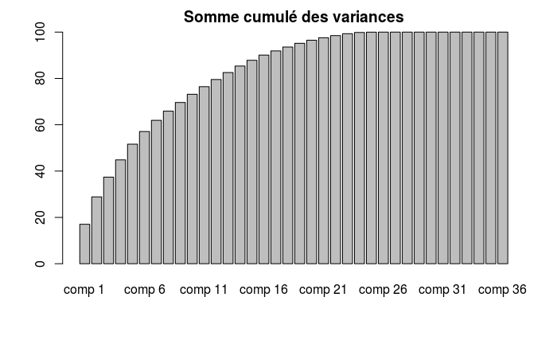

```r
barplot(pockets.acp$eig[,3], main="Somme cumulé des variances")
```

5. To analyze the variability explained by each CP, plot the cumulate sum of data variability explained by the different PCs (= cumulate sum of eigen values).
6. Plot the projection of descriptors in the plane defined by the two first PCs (first PCA plane). This graph allows: • analyzing the correlation between variables • analyzing the first PCA space using descriptors. Analyze this graph: Which descriptors explain the first PC? Which descriptors explain the second PC? Are some descriptors correlated?
7. Plot the projection of pockets in the first PCA plane. What do you observe? Do you observe some outliers? Do you identify some pocket clusters? Explain the identified pocket clusters using variable information.
8. To analyze the druggability according to descriptors, project pockets onto the first PCA plane and color them according to their druggability. What do you observe? Explain druggable and less-druggable pockets in terms of descriptors.
9. To characterize pocket clusers obtained during the mixed procedure (hierarchical classifi- cation + kmeans), project pockets onto the PCA first plane and color them according to the obtained clusters. What do you observe? Explain these clusters using descriptors.
10. Analyze the second PCA plane composed by the third and fourth PCs using the same procedure.

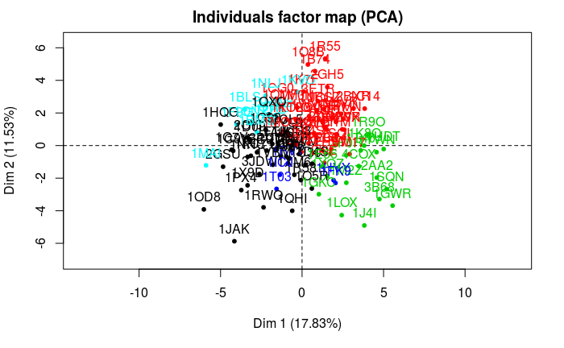

```r
#Couleurs des individus en fonctions des clusters
pockets.kmeans = kmeans(scale(pockets[, -37]), centers = 5)
plot(pockets.acpclusters, choix = "ind", col.ind = pockets.kmeans$cluster)
```

Supplementary questions The PCA analysis is often used as to reduce the dimensionality of data, and for producing insight as to structure of latent variables (cf. Velicer & Jackson, 1990). Instead of working with the original data matrix (n observations describing by p variables), we can work with the c most variable CPs. In this case, these c CPs are the new variables defined as the linear combinations of the p initial variables. There are several approaches to determine how many CPs to retain: • The Kaiser rule (1960) is the best know and most utilized in practice (Fabrigar et. al, 1999). According to this rule, only the CPs that have eigenvalues (variability) greater than one (defined threshold) are retained for interpretation or analysis. • Scree test of Cattell (1966): Cattell’s Scree test corresponds to a visual exploration of a graphical representation of the CP eigenvalues. In this method, the eigenvalues of each CP are in descending order. Afterwards, the graph is examined to determine the elbow point. The CPs before this elbow point are then conserved for future analyses. • The parallel Horn’s analysis (1965). This method is based on the generation of random variables, to determine the number of CPs to retain. This Parallel Analysis (PA) implies a Monte Carlo simulation process, since ‘expected’ eigenvalues are obtained by simulating normal random samples that parallel the observed data in terms of sample size and number of variables. A CP was considered significant if the associated eigenvalue was bigger than the mean of those obtained from the random uncorrelated data. Currently, it is recommended to use the eigenvalue that corresponds to a given percentile, such as the 95th of the distribution of eigenvalues derived from the random data (Cota et al., 1993; Glorfeld, 1995). 1. Using the parallel Horn’s Analysis, compute how many CPs are significant using pocket datasets. 2. Compute a classification of pocket using the mixed approach from c selected CPs. 3. How many pocket clusters do you extract? 4. Analyze these clusters in terms of occurrence and descriptors. 5. Compare these clusters to those obtained using all variables. ##3.3.1 Visualization of the pocket space using Multi Dimensional Scaling (MDS) functions: cmdscale(), dist(). We will use a second method, the Multi Dimensional Scaling (MDS), to visualize the pocket space. The MDS allows you to create a plot translating the pocket space, where two close pockets correspond pockets similar in terms of descriptors. 1. See the help page of the cmdscale() function. What type of input does the cmdscale() function? 2. Compute the MDS on the Euclidean distance matrix between pockets. 3. Plot the pocket projection into the two first axes computed by the MDS. Color pockets according to their druggability. What do you observe? 4. Compare the MDS and PCA results. 5. Color pockets projected into the MDS plane according to clusters obtained by the mixed procedure. What do you observe?